# RQ1, ontology analysis

Processing Citizenship

May 2020

# Outline

This presentation/workbook gives an overview of the work done for the ontology analysis:

1. Work done for coding and organising the atlas.ti project.
2. Modifications and new features of the ontology analysis tool.
3. Outline of methods and data that can be used to answer the research questions.

# Data coding

We went through all codes not yet associated to a code group:

- Assigning codes to already existing groups.
- Renaming and restructuring existing groups.
  - For example organising code groups such as `surname` to `name: surname`.
  - We also created more specific sub-groups. For example, for the code groups `language` we added additional groups `language: reading`, `language: writing`, `language: listening`.
- Creating new code groupings if they could not be grouped in existing structure.

Result is that we can now actually rely on running the analyses based on code groups.

# Ontology analysis tool (1)

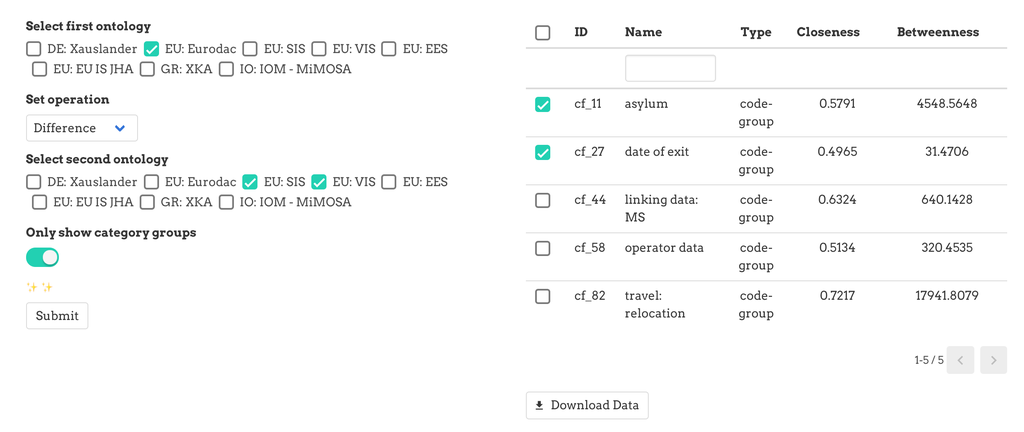

New features

# Ontology analysis tool (2)

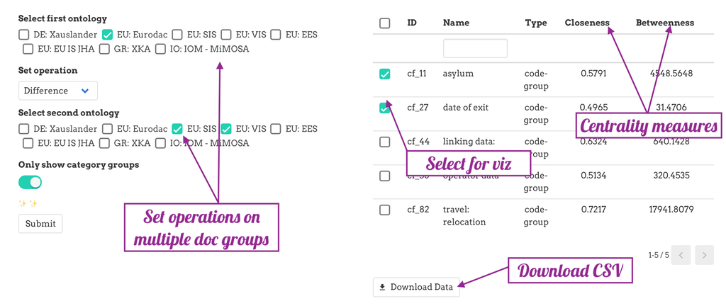

New features

# Data analysis (1)

To do the actual data analysis:

- We reviewed the different proposed methods, questions and hypotheses that were previously formulated.
- For each of these we tried to identify methods and data that can be used to answer the question.
- In many cases this led us to introduce additional specifications of code groups.

# Data analysis (2)

A note on the data used in the following slides. In general the process was a follows:

- Queries were executed in the tool, e.g. intersection of SIS and VIS.
- The output data generated through the graph analysis was downloaded as CSV files.
- These CSV files are directly loaded & processed in generating this presentation.

```r
diff <- read.csv(file="./data/eurodac_particular.csv",head=TRUE,sep=",")
```

- Not all output of this kind of code will be shown in the following slides.

# Question 1

> For each system, which categories are peculiar/native?
- **Method**: Using *set difference* of presence of categories of document group compared to a selection of document groups.
- **Example**: A comparison of categories native to each EU system, in relation to the other EU information systems.
1. For each system
- $Presence(Eurodac) \setminus (Presence(SIS) \bigcup Presence(VIS))$
- $Presence(SIS) \setminus (Presence(Eurodac) \bigcup Presence(VIS))$
- $Presence(VIS) \setminus (Presence(SIS) \bigcup Presence(Eurodac))$
2. Download CSV files

```r
diff_eurodac <- read.csv(file="./data/eurodac_particular.csv",head=TRUE,sep=",")
diff_eurodac <- diff_eurodac[diff_eurodac$node_type == "code-group",]
diff_eurodac <- diff_eurodac$node_name
```

3. Combined results in table

```r
max.len = max(length(diff_eurodac), length(diff_sis), length(diff_vis))
combined <- data.frame(
  eurodac=c(diff_eurodac, rep("", max.len - length(diff_eurodac))),
  sis=c(diff_sis, rep("", max.len - length(diff_sis))),
  vis=c(diff_vis, rep("", max.len - length(diff_vis))))
knitr::kable(combined) %>%
  kable_styling(bootstrap_options = "striped", full_width = F, position = "left")
```

| eurodac | sis | vis |
| --- | --- | --- |
| asylum | additional info / comments | date of application |
| date of exit | criminal offence data | education |
| linking data: MS |  | occupation data |
| operator data |  | occupation data: current |
| travel: relocation |  | parents data |
|  |  | personal ties |
|  |  | personal ties: in EU |
|  |  | residence |
|  |  | stay data |
|  |  | travel data |
|  |  | travel document data |
|  |  | travel document: validity: expiration |
|  |  | travel document: visa-related data |

# Question 2

> For each system, what is the link between the applicant and Europe?
- **Method**: check the presence of a selection of groups code groups that represent links with Europe, such as:
  - `personal ties: in EU`
  - `migrant type` and `migration type`: “family reunification”
  - (future) `occupation` => `employment-interest` (IOM) / “skills”?
  - education
  - family reunification
  - residence
  - previous link with EU: `date of exit`, `return decision`
  - temporary visa & stay
  - …?
- To get more detailed types of links, we decided to further specify some code groups:
  - To distinguish between short, longer, and previous links to Europe.
  - And to distinguish between categories such as current employment vs possible future occupation.
- **Example**: For each EU systems we take the groups of categories present, and filter on the previous selection of code groups.
1. Check data for Eurodac, SIS and VIS & filter on groups

```r
groups <- c("residence", "education", "date of exit", "personal ties: in EU", "migrant type", "travel document: visa-related data", "occupation data: current", "stay data", "linking data: MS")

links_eurodac <- read.csv(file="./data/eurodac.csv",head=TRUE,sep=",")
links_eurodac <- links_eurodac[links_eurodac$node_name %in% groups,]
links_eurodac <- links_eurodac$node_name
```

2. Combine results into a table

```r
max.len = max(length(links_eurodac), length(links_sis), length(links_vis))
combined <- data.frame(
  eurodac=c(links_eurodac, rep("", max.len - length(links_eurodac))),
  sis=c(links_sis, rep("", max.len - length(links_sis))),
  vis=c(links_vis, rep("", max.len - length(links_vis))))
knitr::kable(combined) %>%
  kable_styling(bootstrap_options = "striped", full_width = F, position = "left")
```

| eurodac | sis | vis |
| --- | --- | --- |
| date of exit |  | residence |
| linking data: MS |  | education |
|  |  | occupation data: current |
|  |  | personal ties: in EU |
|  |  | residence |
|  |  | stay data |
|  |  | travel document: visa-related data |

# Question 3

> How is the division of labour between EU and MSs, and among MSs architected, with the mediation of IOs?
- **Method**
  - Comparison of code groups: medical data (+vulnerability), relocation data, asylum, housing, …
  - Do we need to introduce more fine grained code group type for labour type?
- **Ideas**
  - How can we use linking data, e.g. to give indication of kinds of collaboration?
  - Intermediary (same category) vs mediator (different).
  - Can we use extra information from fieldwork?
- **Example** For each EU systems we take the groups of categories present, and filter on the selection of code groups representing types of labour.
1. Check data for Eurodac, SIS, VIS (and XKA) & filter on groups

```r
groups <- c("medical data", "vulnerability", "travel: relocation", "asylum", "Temporary accomodation/housing", "criminal offence data")

links_eurodac <- read.csv(file="./data/eurodac.csv",head=TRUE,sep=",")
links_eurodac <- links_eurodac[links_eurodac$node_name %in% groups,]
links_eurodac <- links_eurodac$node_name
```

2. Combine results into a table

```r
max.len = max(length(links_eurodac), length(links_sis), length(links_vis), length(links_xka))
combined <- data.frame(
  eurodac=c(links_eurodac, rep("", max.len - length(links_eurodac))),
  sis=c(links_sis, rep("", max.len - length(links_sis))),
  vis=c(links_vis, rep("", max.len - length(links_vis))),
  xka=c(links_xka, rep("", max.len - length(links_xka))))
knitr::kable(combined) %>%
  kable_styling(bootstrap_options = "striped", full_width = F, position = "left")
```

| eurodac | sis | vis | xka |
| --- | --- | --- | --- |
| asylum | criminal offence data |  | Temporary accomodation/housing |
| travel: relocation |  |  | asylum |
|  |  |  | travel: relocation |
|  |  |  | vulnerability |

# Question 4

> How does data from some actors become seen as more reliable?
- **Method**: using centrality: more connected nodes gives an indication of categories that are used.
- **Example**: (closeness) centrality of code groups in union of all code groups of Eurodac, SIS, & VIS:

```r
ccn <- read.csv(file="./data/eurodac_sis_vis.csv",head=TRUE,sep=",")
ccn <- ccn[ccn$node_type == "code-group",]
ccn <- ccn[order(ccn$node_centrality_closeness),]
ccn <- ccn[order(ccn$node_centrality_closeness, decreasing=TRUE), c("node_name", "node_centrality_closeness")]
knitr::kable(ccn) %>%
  kable_styling(bootstrap_options = "striped", full_width = F, position = "left")
```

|  | node_name | node_centrality_closeness |
| --- | --- | --- |
| 21 | linking data | 0.7761 |
| 16 | System pre-existant | 0.7757 |
| 15 | System native | 0.7603 |
| 53 | name: surname | 0.7456 |
| 54 | nationality | 0.7456 |
| 48 | birth data: date of birth | 0.7401 |
| 25 | sex & gender | 0.7393 |
| 26 | travel: relocation | 0.7217 |
| 49 | birth data: place of birth | 0.7211 |
| 47 | birth data | 0.7158 |
| 90 | education | 0.7149 |
| 91 | occupation data | 0.7149 |
| 93 | parents data | 0.7121 |
| 94 | personal ties | 0.7120 |
| 99 | travel document data | 0.6976 |
| 18 | biometrics | 0.6950 |
| 52 | name: forename | 0.6901 |
| 98 | travel data | 0.6872 |
| 46 | biometrics: photograph data | 0.6859 |
| 92 | occupation data: current | 0.6353 |
| 22 | linking data: MS | 0.6324 |
| 96 | residence | 0.6145 |
| 45 | additional info / comments | 0.5949 |
| 24 | procedure data | 0.5839 |
| 17 | asylum | 0.5791 |
| 95 | personal ties: in EU | 0.5502 |
| 51 | name: earlier/other names | 0.5471 |
| 97 | stay data | 0.5324 |
| 23 | operator data | 0.5134 |
| 101 | travel document: visa-related data | 0.5031 |
| 19 | biometrics: fingerprint data | 0.5007 |
| 20 | date of exit | 0.4965 |
| 100 | travel document: validity: expiration | 0.4965 |
| 50 | criminal offence data | 0.4946 |
| 89 | date of application | 0.4928 |

# Question 5

> How does data become important to link different systems?
- **Method**: centrality: more connected nodes gives an indication of categories that can connect different data models.
- **Example**: betweenness centrality of code groups of Eurodac, SIS, & VIS:

```r
bc <- read.csv(file="./data/eurodac_sis_vis.csv",head=TRUE,sep=",")
bc <- bc[bc$node_type == "code-group",]
bc <- bc[order(bc$node_centrality_betweenness),]
bc <- bc[order(bc$node_centrality_betweenness, decreasing=TRUE), c("node_name", "node_centrality_betweenness")]
knitr::kable(bc) %>%
  kable_styling(bootstrap_options = "striped", full_width = F, position = "left")
```

|  | node_name | node_centrality_betweenness |
| --- | --- | --- |
| 15 | System native | 48726.6450 |
| 21 | linking data | 46528.0550 |
| 16 | System pre-existant | 32522.9244 |
| 26 | travel: relocation | 17941.8079 |
| 54 | nationality | 16540.1650 |
| 53 | name: surname | 14872.6583 |
| 99 | travel document data | 14659.9675 |
| 94 | personal ties | 12024.0255 |
| 48 | birth data: date of birth | 11242.5091 |
| 25 | sex & gender | 11164.8626 |
| 91 | occupation data | 10713.4330 |
| 18 | biometrics | 9953.5856 |
| 90 | education | 9715.8904 |
| 24 | procedure data | 8291.1812 |
| 49 | birth data: place of birth | 7713.5781 |
| 98 | travel data | 7626.4672 |
| 52 | name: forename | 7482.0087 |
| 96 | residence | 7021.8095 |
| 47 | birth data | 6352.9085 |
| 93 | parents data | 5785.8725 |
| 51 | name: earlier/other names | 5289.7623 |
| 17 | asylum | 4548.5648 |
| 46 | biometrics: photograph data | 3866.2920 |
| 45 | additional info / comments | 3345.8251 |
| 92 | occupation data: current | 1117.9533 |
| 97 | stay data | 965.3354 |
| 22 | linking data: MS | 640.1428 |
| 95 | personal ties: in EU | 541.5667 |
| 23 | operator data | 320.4535 |
| 19 | biometrics: fingerprint data | 296.8501 |
| 101 | travel document: visa-related data | 58.6650 |
| 20 | date of exit | 31.4706 |
| 50 | criminal offence data | 18.3780 |
| 100 | travel document: validity: expiration | 17.3229 |
| 89 | date of application | 1.6949 |

# Open questions

- How are links between different actors mediated through EU, MS, and international organization systems?
- How do some actors become more important?
- How do different social-cultural context in which systems were created enact people differently?
- How are responsibilities between organisations architected?
- When can data modifications become unknown to other actors that reused the data?
- How do travel documents become important for identifying persons?
  - How are id documents and compared to biometrics more/less important for connecting the systems

# Questions and ideas

- Registration data vs application data
- When and for how long are identities stored
- Fylakio xls as disinscription, comparison with XKA and others